# Risk Factor Analysis

## Outcome Variable

**Outcome Variable:** ever_sstunted

## Predictor Variables

**Intervention Variable:** fage

**Adjustment Set:**

unadjusted

## Stratifying Variables

The analysis was stratified on these variable(s):

- agecat
- studyid
- country

## Data Summary

| agecat | studyid | country | fage | ever_sstunted | n_cell | n | outcome_variable |
| --- | --- | --- | --- | --- | --- | --- | --- |
| 0-24 months | ki0047075b-MAL-ED | BANGLADESH | >=38 | 0 | 53 | 151 | ever_sstunted |
| 0-24 months | ki0047075b-MAL-ED | BANGLADESH | >=38 | 1 | 16 | 151 | ever_sstunted |
| 0-24 months | ki0047075b-MAL-ED | BANGLADESH | <32 | 0 | 21 | 151 | ever_sstunted |
| 0-24 months | ki0047075b-MAL-ED | BANGLADESH | <32 | 1 | 9 | 151 | ever_sstunted |
| 0-24 months | ki0047075b-MAL-ED | BANGLADESH | [32-38) | 0 | 41 | 151 | ever_sstunted |
| 0-24 months | ki0047075b-MAL-ED | BANGLADESH | [32-38) | 1 | 11 | 151 | ever_sstunted |
| 0-24 months | ki0047075b-MAL-ED | BRAZIL | >=38 | 0 | 27 | 79 | ever_sstunted |
| 0-24 months | ki0047075b-MAL-ED | BRAZIL | >=38 | 1 | 3 | 79 | ever_sstunted |
| 0-24 months | ki0047075b-MAL-ED | BRAZIL | <32 | 0 | 14 | 79 | ever_sstunted |
| 0-24 months | ki0047075b-MAL-ED | BRAZIL | <32 | 1 | 4 | 79 | ever_sstunted |
| 0-24 months | ki0047075b-MAL-ED | BRAZIL | [32-38) | 0 | 29 | 79 | ever_sstunted |
| 0-24 months | ki0047075b-MAL-ED | BRAZIL | [32-38) | 1 | 2 | 79 | ever_sstunted |
| 0-24 months | ki0047075b-MAL-ED | INDIA | >=38 | 0 | 30 | 161 | ever_sstunted |
| 0-24 months | ki0047075b-MAL-ED | INDIA | >=38 | 1 | 6 | 161 | ever_sstunted |
| 0-24 months | ki0047075b-MAL-ED | INDIA | <32 | 0 | 38 | 161 | ever_sstunted |
| 0-24 months | ki0047075b-MAL-ED | INDIA | <32 | 1 | 15 | 161 | ever_sstunted |
| 0-24 months | ki0047075b-MAL-ED | INDIA | [32-38) | 0 | 57 | 161 | ever_sstunted |
| 0-24 months | ki0047075b-MAL-ED | INDIA | [32-38) | 1 | 15 | 161 | ever_sstunted |
| 0-24 months | ki0047075b-MAL-ED | NEPAL | >=38 | 0 | 16 | 79 | ever_sstunted |
| 0-24 months | ki0047075b-MAL-ED | NEPAL | >=38 | 1 | 1 | 79 | ever_sstunted |
| 0-24 months | ki0047075b-MAL-ED | NEPAL | <32 | 0 | 13 | 79 | ever_sstunted |
| 0-24 months | ki0047075b-MAL-ED | NEPAL | <32 | 1 | 2 | 79 | ever_sstunted |
| 0-24 months | ki0047075b-MAL-ED | NEPAL | [32-38) | 0 | 41 | 79 | ever_sstunted |
| 0-24 months | ki0047075b-MAL-ED | NEPAL | [32-38) | 1 | 6 | 79 | ever_sstunted |
| 0-24 months | ki0047075b-MAL-ED | PERU | >=38 | 0 | 24 | 85 | ever_sstunted |
| 0-24 months | ki0047075b-MAL-ED | PERU | >=38 | 1 | 3 | 85 | ever_sstunted |
| 0-24 months | ki0047075b-MAL-ED | PERU | <32 | 0 | 21 | 85 | ever_sstunted |
| 0-24 months | ki0047075b-MAL-ED | PERU | <32 | 1 | 8 | 85 | ever_sstunted |
| 0-24 months | ki0047075b-MAL-ED | PERU | [32-38) | 0 | 18 | 85 | ever_sstunted |
| 0-24 months | ki0047075b-MAL-ED | PERU | [32-38) | 1 | 11 | 85 | ever_sstunted |

[output cut: 126 more lines]

The following strata were considered:

- agecat: 0-24 months, studyid: ki0047075b-MAL-ED, country: BANGLADESH
- agecat: 0-24 months, studyid: ki0047075b-MAL-ED, country: BRAZIL
- agecat: 0-24 months, studyid: ki0047075b-MAL-ED, country: INDIA
- agecat: 0-24 months, studyid: ki0047075b-MAL-ED, country: NEPAL
- agecat: 0-24 months, studyid: ki0047075b-MAL-ED, country: PERU
- agecat: 0-24 months, studyid: ki0047075b-MAL-ED, country: SOUTH AFRICA
- agecat: 0-24 months, studyid: ki0047075b-MAL-ED, country: TANZANIA, UNITED REPUBLIC OF
- agecat: 0-24 months, studyid: ki1000304b-SAS-CompFeed, country: INDIA
- agecat: 0-24 months, studyid: ki1000304b-SAS-FoodSuppl, country: INDIA
- agecat: 0-24 months, studyid: ki1119695-PROBIT, country: BELARUS
- agecat: 0-24 months, studyid: ki1135781-COHORTS, country: GUATEMALA
- agecat: 0-24 months, studyid: ki1135781-COHORTS, country: PHILIPPINES
- agecat: 0-24 months, studyid: ki1148112-LCNI-5, country: MALAWI
- agecat: 0-6 months, studyid: ki0047075b-MAL-ED, country: BANGLADESH
- agecat: 0-6 months, studyid: ki0047075b-MAL-ED, country: BRAZIL
- agecat: 0-6 months, studyid: ki0047075b-MAL-ED, country: INDIA
- agecat: 0-6 months, studyid: ki0047075b-MAL-ED, country: NEPAL
- agecat: 0-6 months, studyid: ki0047075b-MAL-ED, country: PERU
- agecat: 0-6 months, studyid: ki0047075b-MAL-ED, country: SOUTH AFRICA
- agecat: 0-6 months, studyid: ki0047075b-MAL-ED, country: TANZANIA, UNITED REPUBLIC OF
- agecat: 0-6 months, studyid: ki1000304b-SAS-CompFeed, country: INDIA
- agecat: 0-6 months, studyid: ki1000304b-SAS-FoodSuppl, country: INDIA
- agecat: 0-6 months, studyid: ki1119695-PROBIT, country: BELARUS
- agecat: 0-6 months, studyid: ki1135781-COHORTS, country: GUATEMALA
- agecat: 0-6 months, studyid: ki1135781-COHORTS, country: PHILIPPINES
- agecat: 0-6 months, studyid: ki1148112-LCNI-5, country: MALAWI

### Dropped Strata

Some strata were dropped due to rare outcomes:

- agecat: 0-24 months, studyid: ki0047075b-MAL-ED, country: BRAZIL
- agecat: 0-24 months, studyid: ki0047075b-MAL-ED, country: NEPAL
- agecat: 0-24 months, studyid: ki0047075b-MAL-ED, country: PERU
- agecat: 0-24 months, studyid: ki0047075b-MAL-ED, country: SOUTH AFRICA
- agecat: 0-24 months, studyid: ki0047075b-MAL-ED, country: TANZANIA, UNITED REPUBLIC OF
- agecat: 0-24 months, studyid: ki1148112-LCNI-5, country: MALAWI
- agecat: 0-6 months, studyid: ki0047075b-MAL-ED, country: BANGLADESH
- agecat: 0-6 months, studyid: ki0047075b-MAL-ED, country: BRAZIL
- agecat: 0-6 months, studyid: ki0047075b-MAL-ED, country: INDIA
- agecat: 0-6 months, studyid: ki0047075b-MAL-ED, country: NEPAL
- agecat: 0-6 months, studyid: ki0047075b-MAL-ED, country: PERU
- agecat: 0-6 months, studyid: ki0047075b-MAL-ED, country: SOUTH AFRICA
- agecat: 0-6 months, studyid: ki0047075b-MAL-ED, country: TANZANIA, UNITED REPUBLIC OF
- agecat: 0-6 months, studyid: ki1148112-LCNI-5, country: MALAWI

## Methods Detail

We’re interested in the causal parameters $E[Y_a]$ for all values of $a \in \mathcal{A}$. These parameters represent the mean outcome if, possibly contrary to fact, we intervened to set all units to have $A=a$. Under the randomization and positivity assumptions, these are identified by the statistical parameters $\psi_a=E_W[E_{Y|A,W}(Y|A=a,W)]$. In addition, we’re interested in the mean of $Y$, $E[Y]$ under no intervention (the observed mean). We will estimate these parameters by using SuperLearner to fit the relevant likelihood factors – $E_{Y|A,W}(Y|A=a,W)$ and $p(A=a|W)$, and then updating our likelihood fit using a joint TMLE.

For unadjusted analyses ($W=\{\}$), initial likelihoods were estimated using Lrnr_glm to estimate the simple $E(Y|A)$ and Lrnr_mean to estimate $p(A)$. For adjusted analyses, a small library containing Lrnr_glmnet, Lrnr_xgboost, and Lrnr_mean was used.

Having estimated these parameters, we will then use the delta method to estimate relative risks and attributable risks relative to a prespecified baseline level of $A$.

# Results Detail

## Results Plots

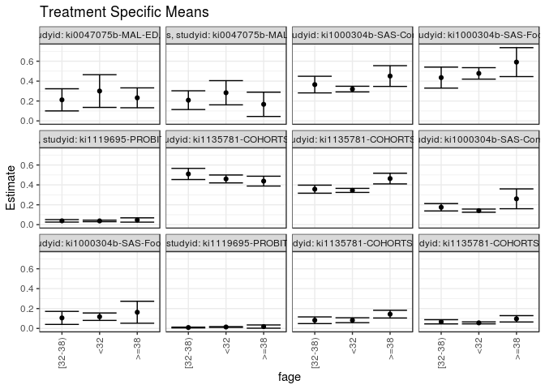

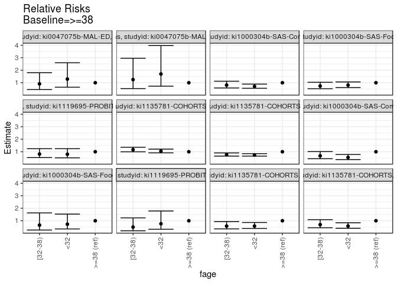

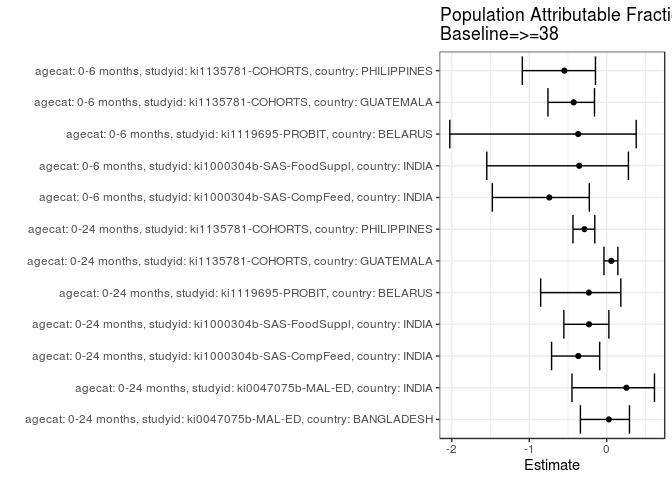

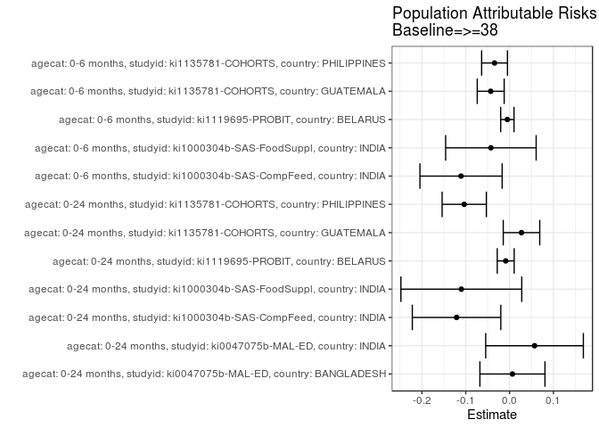

## Results Table

### Parameter: TSM

| agecat | studyid | country | intervention_level | baseline_level | estimate | ci_lower | ci_upper |
| --- | --- | --- | --- | --- | --- | --- | --- |
| 0-24 months | ki0047075b-MAL-ED | BANGLADESH | >=38 | NA | 0.2318841 | 0.1319726 | 0.3317955 |
| 0-24 months | ki0047075b-MAL-ED | BANGLADESH | <32 | NA | 0.3000000 | 0.1354719 | 0.4645281 |
| 0-24 months | ki0047075b-MAL-ED | BANGLADESH | [32-38) | NA | 0.2115385 | 0.1001669 | 0.3229100 |
| 0-24 months | ki0047075b-MAL-ED | INDIA | >=38 | NA | 0.1666667 | 0.0445476 | 0.2887858 |
| 0-24 months | ki0047075b-MAL-ED | INDIA | <32 | NA | 0.2830189 | 0.1613654 | 0.4046724 |
| 0-24 months | ki0047075b-MAL-ED | INDIA | [32-38) | NA | 0.2083333 | 0.1142343 | 0.3024324 |
| 0-24 months | ki1000304b-SAS-CompFeed | INDIA | >=38 | NA | 0.4509804 | 0.3466421 | 0.5553187 |
| 0-24 months | ki1000304b-SAS-CompFeed | INDIA | <32 | NA | 0.3197811 | 0.2914132 | 0.3481490 |
| 0-24 months | ki1000304b-SAS-CompFeed | INDIA | [32-38) | NA | 0.3650000 | 0.2813265 | 0.4486735 |
| 0-24 months | ki1000304b-SAS-FoodSuppl | INDIA | >=38 | NA | 0.5909091 | 0.4454596 | 0.7363585 |
| 0-24 months | ki1000304b-SAS-FoodSuppl | INDIA | <32 | NA | 0.4775087 | 0.4198520 | 0.5351653 |
| 0-24 months | ki1000304b-SAS-FoodSuppl | INDIA | [32-38) | NA | 0.4352941 | 0.3297677 | 0.5408206 |
| 0-24 months | ki1119695-PROBIT | BELARUS | >=38 | NA | 0.0470430 | 0.0254449 | 0.0686411 |
| 0-24 months | ki1119695-PROBIT | BELARUS | <32 | NA | 0.0376781 | 0.0299710 | 0.0453851 |
| 0-24 months | ki1119695-PROBIT | BELARUS | [32-38) | NA | 0.0383838 | 0.0259062 | 0.0508615 |
| 0-24 months | ki1135781-COHORTS | GUATEMALA | >=38 | NA | 0.4378238 | 0.3883122 | 0.4873355 |
| 0-24 months | ki1135781-COHORTS | GUATEMALA | <32 | NA | 0.4597701 | 0.4201728 | 0.4993675 |
| 0-24 months | ki1135781-COHORTS | GUATEMALA | [32-38) | NA | 0.5098039 | 0.4537713 | 0.5658365 |
| 0-24 months | ki1135781-COHORTS | PHILIPPINES | >=38 | NA | 0.4636364 | 0.4098239 | 0.5174489 |
| 0-24 months | ki1135781-COHORTS | PHILIPPINES | <32 | NA | 0.3446952 | 0.3242817 | 0.3651086 |
| 0-24 months | ki1135781-COHORTS | PHILIPPINES | [32-38) | NA | 0.3568773 | 0.3163883 | 0.3973663 |
| 0-6 months | ki1000304b-SAS-CompFeed | INDIA | >=38 | NA | 0.2600000 | 0.1601998 | 0.3598002 |
| 0-6 months | ki1000304b-SAS-CompFeed | INDIA | <32 | NA | 0.1409554 | 0.1251663 | 0.1567444 |
| 0-6 months | ki1000304b-SAS-CompFeed | INDIA | [32-38) | NA | 0.1750000 | 0.1378969 | 0.2121031 |
| 0-6 months | ki1000304b-SAS-FoodSuppl | INDIA | >=38 | NA | 0.1627907 | 0.0523146 | 0.2732668 |
| 0-6 months | ki1000304b-SAS-FoodSuppl | INDIA | <32 | NA | 0.1180556 | 0.0807444 | 0.1553667 |
| 0-6 months | ki1000304b-SAS-FoodSuppl | INDIA | [32-38) | NA | 0.1058824 | 0.0403931 | 0.1713717 |
| 0-6 months | ki1119695-PROBIT | BELARUS | >=38 | NA | 0.0188425 | 0.0025412 | 0.0351439 |
| 0-6 months | ki1119695-PROBIT | BELARUS | <32 | NA | 0.0143229 | 0.0106071 | 0.0180387 |
| 0-6 months | ki1119695-PROBIT | BELARUS | [32-38) | NA | 0.0092967 | 0.0051929 | 0.0134004 |
| 0-6 months | ki1135781-COHORTS | GUATEMALA | >=38 | NA | 0.1437700 | 0.1048823 | 0.1826576 |
| 0-6 months | ki1135781-COHORTS | GUATEMALA | <32 | NA | 0.0826446 | 0.0581027 | 0.1071865 |
| 0-6 months | ki1135781-COHORTS | GUATEMALA | [32-38) | NA | 0.0823529 | 0.0485961 | 0.1161098 |
| 0-6 months | ki1135781-COHORTS | PHILIPPINES | >=38 | NA | 0.0969697 | 0.0650371 | 0.1289023 |
| 0-6 months | ki1135781-COHORTS | PHILIPPINES | <32 | NA | 0.0561690 | 0.0462795 | 0.0660584 |
| 0-6 months | ki1135781-COHORTS | PHILIPPINES | [32-38) | NA | 0.0669145 | 0.0457966 | 0.0880324 |

### Parameter: E(Y)

| agecat | studyid | country | intervention_level | baseline_level | estimate | ci_lower | ci_upper |
| --- | --- | --- | --- | --- | --- | --- | --- |
| 0-24 months | ki0047075b-MAL-ED | BANGLADESH | NA | NA | 0.2384106 | 0.1702198 | 0.3066014 |
| 0-24 months | ki0047075b-MAL-ED | INDIA | NA | NA | 0.2236025 | 0.1590417 | 0.2881632 |
| 0-24 months | ki1000304b-SAS-CompFeed | INDIA | NA | NA | 0.3300654 | 0.3020915 | 0.3580392 |
| 0-24 months | ki1000304b-SAS-FoodSuppl | INDIA | NA | NA | 0.4808612 | 0.4329065 | 0.5288160 |
| 0-24 months | ki1119695-PROBIT | BELARUS | NA | NA | 0.0382134 | 0.0300125 | 0.0464143 |
| 0-24 months | ki1135781-COHORTS | GUATEMALA | NA | NA | 0.4650269 | 0.4379137 | 0.4921401 |
| 0-24 months | ki1135781-COHORTS | PHILIPPINES | NA | NA | 0.3602169 | 0.3428934 | 0.3775404 |
| 0-6 months | ki1000304b-SAS-CompFeed | INDIA | NA | NA | 0.1493124 | 0.1303783 | 0.1682465 |
| 0-6 months | ki1000304b-SAS-FoodSuppl | INDIA | NA | NA | 0.1201923 | 0.0889059 | 0.1514788 |
| 0-6 months | ki1119695-PROBIT | BELARUS | NA | NA | 0.0137651 | 0.0103766 | 0.0171537 |
| 0-6 months | ki1135781-COHORTS | GUATEMALA | NA | NA | 0.1007605 | 0.0825622 | 0.1189587 |
| 0-6 months | ki1135781-COHORTS | PHILIPPINES | NA | NA | 0.0626906 | 0.0539432 | 0.0714380 |

### Parameter: RR

| agecat | studyid | country | intervention_level | baseline_level | estimate | ci_lower | ci_upper |
| --- | --- | --- | --- | --- | --- | --- | --- |
| 0-24 months | ki0047075b-MAL-ED | BANGLADESH | >=38 | >=38 | 1.0000000 | 1.0000000 | 1.0000000 |
| 0-24 months | ki0047075b-MAL-ED | BANGLADESH | <32 | >=38 | 1.2937500 | 0.6441055 | 2.5986255 |
| 0-24 months | ki0047075b-MAL-ED | BANGLADESH | [32-38) | >=38 | 0.9122596 | 0.4620194 | 1.8012613 |
| 0-24 months | ki0047075b-MAL-ED | INDIA | >=38 | >=38 | 1.0000000 | 1.0000000 | 1.0000000 |
| 0-24 months | ki0047075b-MAL-ED | INDIA | <32 | >=38 | 1.6981132 | 0.7261684 | 3.9709637 |
| 0-24 months | ki0047075b-MAL-ED | INDIA | [32-38) | >=38 | 1.2500000 | 0.5285589 | 2.9561513 |
| 0-24 months | ki1000304b-SAS-CompFeed | INDIA | >=38 | >=38 | 1.0000000 | 1.0000000 | 1.0000000 |
| 0-24 months | ki1000304b-SAS-CompFeed | INDIA | <32 | >=38 | 0.7090798 | 0.5624118 | 0.8939965 |
| 0-24 months | ki1000304b-SAS-CompFeed | INDIA | [32-38) | >=38 | 0.8093478 | 0.5818903 | 1.1257172 |
| 0-24 months | ki1000304b-SAS-FoodSuppl | INDIA | >=38 | >=38 | 1.0000000 | 1.0000000 | 1.0000000 |
| 0-24 months | ki1000304b-SAS-FoodSuppl | INDIA | <32 | >=38 | 0.8080916 | 0.6143162 | 1.0629900 |
| 0-24 months | ki1000304b-SAS-FoodSuppl | INDIA | [32-38) | >=38 | 0.7366516 | 0.5214604 | 1.0406459 |
| 0-24 months | ki1119695-PROBIT | BELARUS | >=38 | >=38 | 1.0000000 | 1.0000000 | 1.0000000 |
| 0-24 months | ki1119695-PROBIT | BELARUS | <32 | >=38 | 0.8009277 | 0.5148760 | 1.2459025 |
| 0-24 months | ki1119695-PROBIT | BELARUS | [32-38) | >=38 | 0.8159307 | 0.5340834 | 1.2465149 |
| 0-24 months | ki1135781-COHORTS | GUATEMALA | >=38 | >=38 | 1.0000000 | 1.0000000 | 1.0000000 |
| 0-24 months | ki1135781-COHORTS | GUATEMALA | <32 | >=38 | 1.0501258 | 0.9109776 | 1.2105284 |
| 0-24 months | ki1135781-COHORTS | GUATEMALA | [32-38) | >=38 | 1.1644042 | 0.9945267 | 1.3632989 |
| 0-24 months | ki1135781-COHORTS | PHILIPPINES | >=38 | >=38 | 1.0000000 | 1.0000000 | 1.0000000 |
| 0-24 months | ki1135781-COHORTS | PHILIPPINES | <32 | >=38 | 0.7434601 | 0.6526319 | 0.8469291 |
| 0-24 months | ki1135781-COHORTS | PHILIPPINES | [32-38) | >=38 | 0.7697354 | 0.6544148 | 0.9053778 |
| 0-6 months | ki1000304b-SAS-CompFeed | INDIA | >=38 | >=38 | 1.0000000 | 1.0000000 | 1.0000000 |
| 0-6 months | ki1000304b-SAS-CompFeed | INDIA | <32 | >=38 | 0.5421360 | 0.3746370 | 0.7845233 |
| 0-6 months | ki1000304b-SAS-CompFeed | INDIA | [32-38) | >=38 | 0.6730769 | 0.4455215 | 1.0168590 |
| 0-6 months | ki1000304b-SAS-FoodSuppl | INDIA | >=38 | >=38 | 1.0000000 | 1.0000000 | 1.0000000 |
| 0-6 months | ki1000304b-SAS-FoodSuppl | INDIA | <32 | >=38 | 0.7251984 | 0.3430315 | 1.5331325 |
| 0-6 months | ki1000304b-SAS-FoodSuppl | INDIA | [32-38) | >=38 | 0.6504202 | 0.2596698 | 1.6291705 |
| 0-6 months | ki1119695-PROBIT | BELARUS | >=38 | >=38 | 1.0000000 | 1.0000000 | 1.0000000 |
| 0-6 months | ki1119695-PROBIT | BELARUS | <32 | >=38 | 0.7601376 | 0.3242828 | 1.7818065 |
| 0-6 months | ki1119695-PROBIT | BELARUS | [32-38) | >=38 | 0.4933884 | 0.1979451 | 1.2297963 |
| 0-6 months | ki1135781-COHORTS | GUATEMALA | >=38 | >=38 | 1.0000000 | 1.0000000 | 1.0000000 |
| 0-6 months | ki1135781-COHORTS | GUATEMALA | <32 | >=38 | 0.5748393 | 0.3846801 | 0.8590001 |
| 0-6 months | ki1135781-COHORTS | GUATEMALA | [32-38) | >=38 | 0.5728105 | 0.3505313 | 0.9360415 |
| 0-6 months | ki1135781-COHORTS | PHILIPPINES | >=38 | >=38 | 1.0000000 | 1.0000000 | 1.0000000 |
| 0-6 months | ki1135781-COHORTS | PHILIPPINES | <32 | >=38 | 0.5792427 | 0.3987377 | 0.8414607 |
| 0-6 months | ki1135781-COHORTS | PHILIPPINES | [32-38) | >=38 | 0.6900558 | 0.4373160 | 1.0888625 |

### Parameter: PAR

| agecat | studyid | country | intervention_level | baseline_level | estimate | ci_lower | ci_upper |
| --- | --- | --- | --- | --- | --- | --- | --- |
| 0-24 months | ki0047075b-MAL-ED | BANGLADESH | >=38 | NA | 0.0065265 | -0.0676987 | 0.0807518 |
| 0-24 months | ki0047075b-MAL-ED | INDIA | >=38 | NA | 0.0569358 | -0.0544732 | 0.1683448 |
| 0-24 months | ki1000304b-SAS-CompFeed | INDIA | >=38 | NA | -0.1209150 | -0.2218582 | -0.0199719 |
| 0-24 months | ki1000304b-SAS-FoodSuppl | INDIA | >=38 | NA | -0.1100478 | -0.2478934 | 0.0277977 |
| 0-24 months | ki1119695-PROBIT | BELARUS | >=38 | NA | -0.0088296 | -0.0281244 | 0.0104653 |
| 0-24 months | ki1135781-COHORTS | GUATEMALA | >=38 | NA | 0.0272031 | -0.0144130 | 0.0688191 |
| 0-24 months | ki1135781-COHORTS | PHILIPPINES | >=38 | NA | -0.1034195 | -0.1538996 | -0.0529394 |
| 0-6 months | ki1000304b-SAS-CompFeed | INDIA | >=38 | NA | -0.1106876 | -0.2044488 | -0.0169264 |
| 0-6 months | ki1000304b-SAS-FoodSuppl | INDIA | >=38 | NA | -0.0425984 | -0.1458489 | 0.0606521 |
| 0-6 months | ki1119695-PROBIT | BELARUS | >=38 | NA | -0.0050774 | -0.0202624 | 0.0101076 |
| 0-6 months | ki1135781-COHORTS | GUATEMALA | >=38 | NA | -0.0430095 | -0.0737268 | -0.0122922 |
| 0-6 months | ki1135781-COHORTS | PHILIPPINES | >=38 | NA | -0.0342791 | -0.0637435 | -0.0048147 |

### Parameter: PAF

| agecat | studyid | country | intervention_level | baseline_level | estimate | ci_lower | ci_upper |
| --- | --- | --- | --- | --- | --- | --- | --- |
| 0-24 months | ki0047075b-MAL-ED | BANGLADESH | >=38 | NA | 0.0273752 | -0.3395046 | 0.2937695 |
| 0-24 months | ki0047075b-MAL-ED | INDIA | >=38 | NA | 0.2546296 | -0.4483342 | 0.6164028 |
| 0-24 months | ki1000304b-SAS-CompFeed | INDIA | >=38 | NA | -0.3663366 | -0.7116476 | -0.0906893 |
| 0-24 months | ki1000304b-SAS-FoodSuppl | INDIA | >=38 | NA | -0.2288557 | -0.5531769 | 0.0277435 |
| 0-24 months | ki1119695-PROBIT | BELARUS | >=38 | NA | -0.2310596 | -0.8525742 | 0.1819449 |
| 0-24 months | ki1135781-COHORTS | GUATEMALA | >=38 | NA | 0.0584978 | -0.0354305 | 0.1439055 |
| 0-24 months | ki1135781-COHORTS | PHILIPPINES | >=38 | NA | -0.2871034 | -0.4354955 | -0.1540511 |
| 0-6 months | ki1000304b-SAS-CompFeed | INDIA | >=38 | NA | -0.7413158 | -1.4765902 | -0.2243369 |
| 0-6 months | ki1000304b-SAS-FoodSuppl | INDIA | >=38 | NA | -0.3544186 | -1.5480213 | 0.2800493 |
| 0-6 months | ki1119695-PROBIT | BELARUS | >=38 | NA | -0.3688594 | -2.0259985 | 0.3807743 |
| 0-6 months | ki1135781-COHORTS | GUATEMALA | >=38 | NA | -0.4268491 | -0.7584372 | -0.1577885 |
| 0-6 months | ki1135781-COHORTS | PHILIPPINES | >=38 | NA | -0.5467977 | -1.0893359 | -0.1451405 |